# Class

class

Alireza Darvishi

2020-08-13 22:52:09

# Loading data and packages

```r
library(readxl)
library(tidyverse)
library(glmnet)
library(verification)
data <- read_excel("default of credit card clients.xls")
```

## Data description

This research employed a binary variable, default payment (Yes = 1, No = 0), as the response variable. This study used the following 23 variables as explanatory variables

Amount of the given credit (NT dollar): it includes both the individual consumer credit and his/her family (supplementary) credit.

Gender (1 = male; 2 = female).

Education (0 = unknown; 1 = graduate school; 2 = university; 3 = high school; 4 = others).

Marital status (0 = unknown; 1 = married; 2 = single; 3 = others).

Age (year).

PAY_1 - PAY_6 : History of past payment. We tracked the past monthly payment records (from April to September, 2005) as follows: PAY_1 = the repayment status in September, 2005; PAY_2 = the repayment status in August, 2005; . . .;PAY_6 = the repayment status in April, 2005. The measurement scale for the repayment status is: -1 = pay duly; 1 = payment delay for one month; 2 = payment delay for two months; . . .; 8 = payment delay for eight months; 9 = payment delay for nine months and above.

Amount of bill statement (NT dollar). BIL_AMT1 = amount of bill statement in September, 2005; BIL_AMT2 = amount of bill statement in August, 2005; . . .; BIL_AMT6 = amount of bill statement in April, 2005.

Amount of previous payment (NT dollar). PAY_AMT1 = amount paid in September, 2005; PAY_AMT2 = amount paid in August, 2005; . . .;PAY_AMT6 = amount paid in April, 2005.

## Preprocess and data summary

```r
data$SEX = as.factor(data$SEX)
data$EDUCATION = as.factor(data$EDUCATION)
data$MARRIAGE = as.factor(data$MARRIAGE)
data$def_pymnt_nxt_mnth = as.factor(data$def_pymnt_nxt_mnth)
summary(data[,-1])
```

```
   LIMIT_BAL         SEX          EDUCATION     MARRIAGE          AGE            PAY_1
 Min.   :  10000   1   :11888   2      :14030   0   :   54   Min.   :21.00   Min.   :-1.0000
 1st Qu.:  50000   2   :18112   1      :10585   1   :13659   1st Qu.:28.00   1st Qu.: 1.0000
 Median : 140000   NA's:35535   3      : 4917   2   :15964   Median :34.00   Median : 1.0000
 Mean   : 167484                5      :  280   3   :  323   Mean   :35.49   Mean   : 0.9924
 3rd Qu.: 240000                4      :  123   NA's:35535   3rd Qu.:41.00   3rd Qu.: 1.0000
 Max.   :1000000                (Other):   65                Max.   :79.00   Max.   : 9.0000
 NA's   :35535                  NA's   :35535                NA's   :35535
     PAY_2             PAY_3             PAY_4            PAY_5             PAY_6           BILL_AMT1
 Min.   :-1.0000   Min.   :-1.0000   Min.   :-1.000   Min.   :-1.0000   Min.   :-1.0000   Min.   :-165580
 1st Qu.: 1.0000   1st Qu.: 1.0000   1st Qu.: 1.000   1st Qu.: 1.0000   1st Qu.: 1.0000   1st Qu.:   3559
 Median : 1.0000   Median : 1.0000   Median : 1.000   Median : 1.0000   Median : 1.0000   Median :  22382
 Mean   : 0.9388   Mean   : 0.9239   Mean   : 0.899   Mean   : 0.8781   Mean   : 0.8667   Mean   :  51223
 3rd Qu.: 1.0000   3rd Qu.: 1.0000   3rd Qu.: 1.000   3rd Qu.: 1.0000   3rd Qu.: 1.0000   3rd Qu.:  67091
 Max.   : 9.0000   Max.   : 9.0000   Max.   : 9.000   Max.   : 9.0000   Max.   : 9.0000   Max.   : 964511
                                                                                          NA's   :35535
   BILL_AMT2        BILL_AMT3         BILL_AMT4         BILL_AMT5        BILL_AMT6          PAY_AMT1
 Min.   :-69777   Min.   :-157264   Min.   :-170000   Min.   :-81334   Min.   :-339603   Min.   :     0
 1st Qu.:  2985   1st Qu.:   2666   1st Qu.:   2327   1st Qu.:  1763   1st Qu.:   1256   1st Qu.:  1000
 Median : 21200   Median :  20088   Median :  19052   Median : 18104   Median :  17071   Median :  2100
 Mean   : 49179   Mean   :  47013   Mean   :  43263   Mean   : 40311   Mean   :  38872   Mean   :  5664
 3rd Qu.: 64006   3rd Qu.:  60165   3rd Qu.:  54506   3rd Qu.: 50190   3rd Qu.:  49198   3rd Qu.:  5006
 Max.   :983931   Max.   :1664089   Max.   : 891586   Max.   :927171   Max.   : 961664   Max.   :873552
 NA's   :35535    NA's   :35535     NA's   :35535     NA's   :35535    NA's   :35535     NA's   :35535
    PAY_AMT2          PAY_AMT3         PAY_AMT4         PAY_AMT5           PAY_AMT6
 Min.   :      0   Min.   :     0   Min.   :     0   Min.   :     0.0   Min.   :     0.0
 1st Qu.:    833   1st Qu.:   390   1st Qu.:   296   1st Qu.:   252.5   1st Qu.:   117.8
 Median :   2009   Median :  1800   Median :  1500   Median :  1500.0   Median :  1500.0
 Mean   :   5921   Mean   :  5226   Mean   :  4826   Mean   :  4799.4   Mean   :  5215.5
 3rd Qu.:   5000   3rd Qu.:  4505   3rd Qu.:  4013   3rd Qu.:  4031.5   3rd Qu.:  4000.0
 Max.   :1684259   Max.   :896040   Max.   :621000   Max.   :426529.0   Max.   :528666.0
 NA's   :35535     NA's   :35535    NA's   :35535    NA's   :35535      NA's   :35535
 def_pymnt_nxt_mnth
 0   :23364
 1   : 6636
 NA's:35535
```

# Visualization

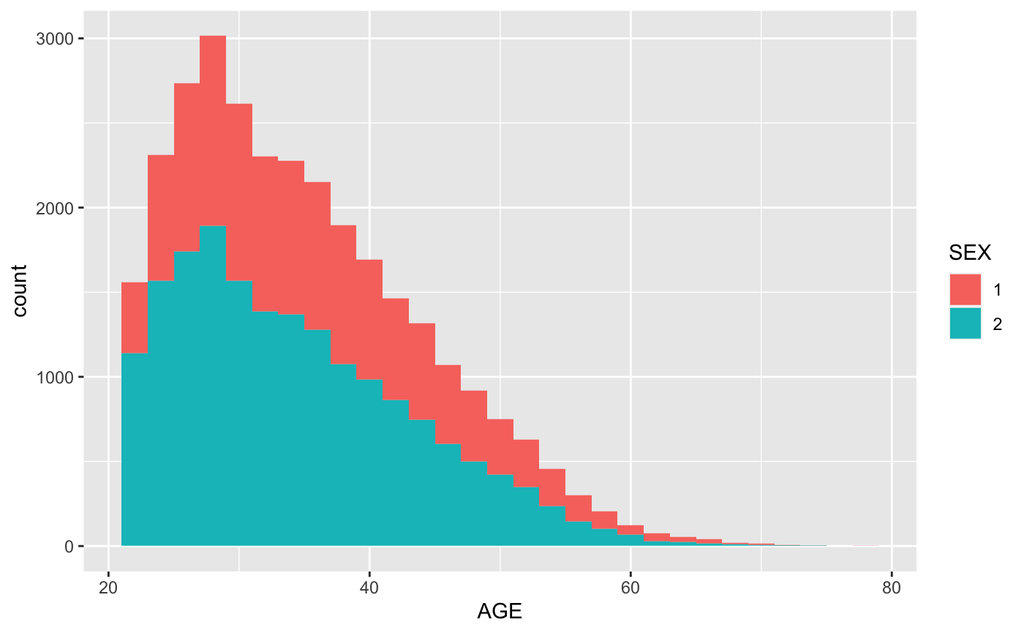

```r
ggplot(data) +
  geom_histogram(
    aes(x=AGE,fill = SEX),
    bins = 30)
```

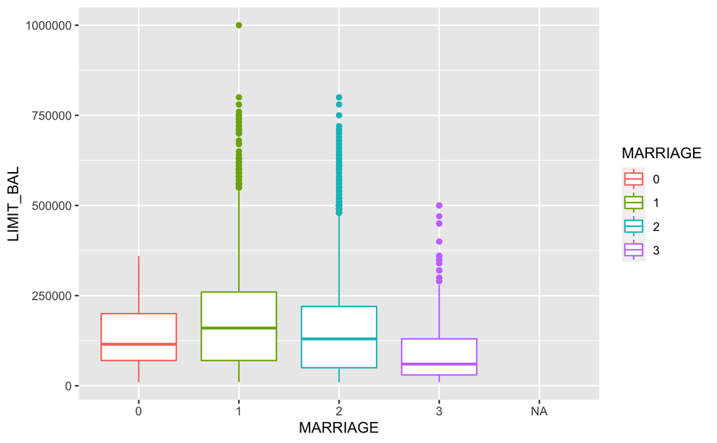

```r
ggplot(data) +
  geom_boxplot(
    aes(y=LIMIT_BAL,
        color = MARRIAGE , x = MARRIAGE))
```

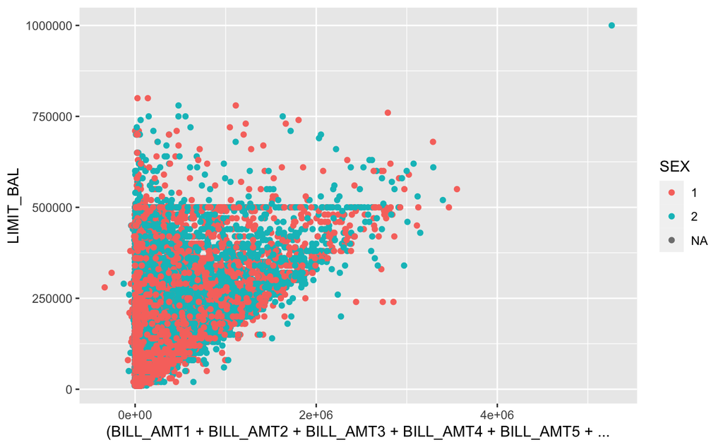

```r
ggplot(data) +
  geom_point(
    aes(color = SEX ,
        y=LIMIT_BAL,
        x = (BILL_AMT1+BILL_AMT2+BILL_AMT3+
               BILL_AMT4+BILL_AMT5+BILL_AMT6)))
```

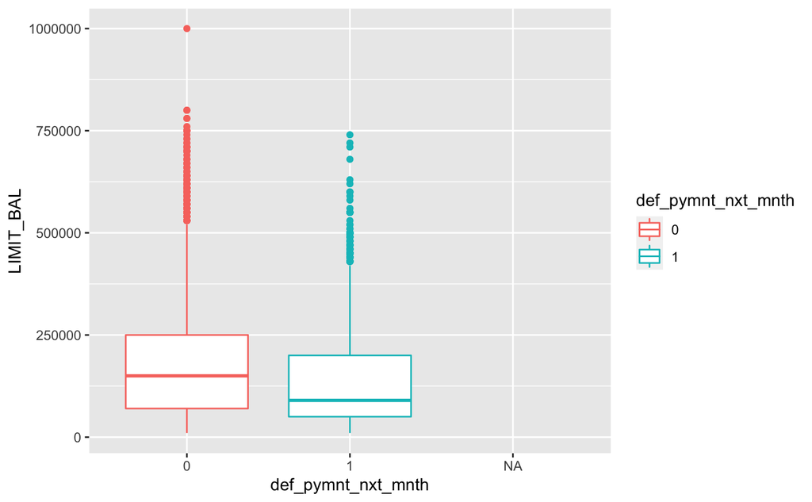

```r
ggplot(data) +
  geom_boxplot(
    aes(y=LIMIT_BAL,
        color = def_pymnt_nxt_mnth ,
        x = def_pymnt_nxt_mnth))
```

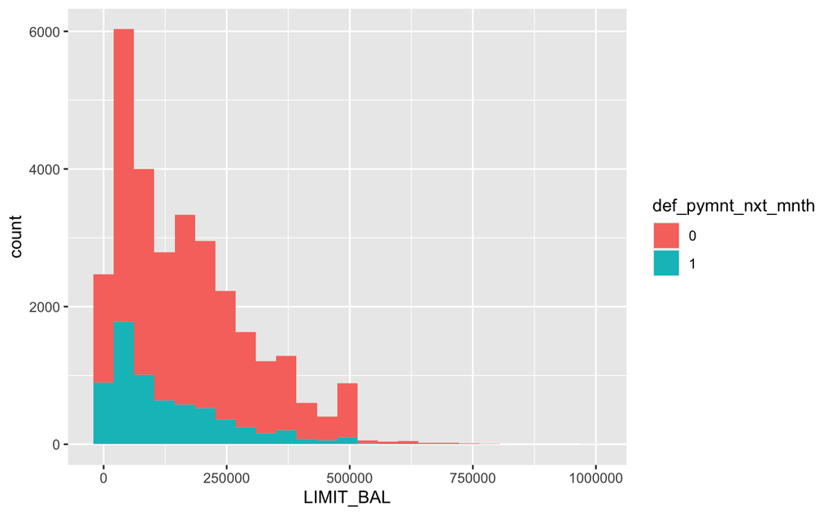

```r
ggplot(data) +
  geom_histogram(
    aes(fill = def_pymnt_nxt_mnth ,
        x = LIMIT_BAL),bins=25)
```

# Data manipulation

```r
data = na.omit(data)
cor(data[,7:12])
```

```
          PAY_1     PAY_2     PAY_3     PAY_4     PAY_5     PAY_6
PAY_1 1.0000000 0.6721644 0.5742451 0.5388406 0.5094261 0.4745531
PAY_2 0.6721644 1.0000000 0.7665517 0.6620671 0.6227802 0.5755009
PAY_3 0.5742451 0.7665517 1.0000000 0.7773589 0.6867745 0.6326836
PAY_4 0.5388406 0.6620671 0.7773589 1.0000000 0.8198353 0.7164495
PAY_5 0.5094261 0.6227802 0.6867745 0.8198353 1.0000000 0.8169002
PAY_6 0.4745531 0.5755009 0.6326836 0.7164495 0.8169002 1.0000000
```

```r
cor(data[,13:18])
```

```
          BILL_AMT1 BILL_AMT2 BILL_AMT3 BILL_AMT4 BILL_AMT5 BILL_AMT6
BILL_AMT1 1.0000000 0.9514837 0.8922785 0.8602722 0.8297786 0.8026502
BILL_AMT2 0.9514837 1.0000000 0.9283263 0.8924823 0.8597783 0.8315936
BILL_AMT3 0.8922785 0.9283263 1.0000000 0.9239695 0.8839097 0.8533201
BILL_AMT4 0.8602722 0.8924823 0.9239695 1.0000000 0.9401344 0.9009410
BILL_AMT5 0.8297786 0.8597783 0.8839097 0.9401344 1.0000000 0.9461968
BILL_AMT6 0.8026502 0.8315936 0.8533201 0.9009410 0.9461968 1.0000000
```

```r
cor(data[,19:24])
```

```
          PAY_AMT1  PAY_AMT2  PAY_AMT3  PAY_AMT4  PAY_AMT5  PAY_AMT6
PAY_AMT1 1.0000000 0.2855755 0.2521911 0.1995579 0.1484593 0.1857353
PAY_AMT2 0.2855755 1.0000000 0.2447705 0.1801067 0.1809078 0.1576339
PAY_AMT3 0.2521911 0.2447705 1.0000000 0.2163251 0.1592137 0.1627400
PAY_AMT4 0.1995579 0.1801067 0.2163251 1.0000000 0.1518304 0.1578339
PAY_AMT5 0.1484593 0.1809078 0.1592137 0.1518304 1.0000000 0.1548955
PAY_AMT6 0.1857353 0.1576339 0.1627400 0.1578339 0.1548955 1.0000000
```

As we can see PAYs are correlated with each other and BILLs are correlated with each other as well.

So we summarise these data to lower dimension using linear transformations below.

But PAY_AMTs are not correlated so we keep theme and regularize it with credit limit value.

```r
data %>% mutate(PAY_AMT_SUM=
                  PAY_1*PAY_AMT1+PAY_2*PAY_AMT2+
                  PAY_3*PAY_AMT3+PAY_4*PAY_AMT4+
                  PAY_5*PAY_AMT5+PAY_6*PAY_AMT6 ,
                REGULARIZED_BILL =
                  PAY_1*BILL_AMT1 +PAY_2*BILL_AMT2 +
                  PAY_3*BILL_AMT3 +PAY_4*BILL_AMT4 +
                  PAY_5*BILL_AMT5 +PAY_6*BILL_AMT6 ,
                PAY_MEAN = PAY_1/6+PAY_2/6+PAY_3/6+
                  PAY_4/6+PAY_5/6+PAY_6/6 ,
                PAY_RATIO1 = PAY_AMT1/LIMIT_BAL ,
                PAY_RATIO2 = PAY_AMT2/LIMIT_BAL ,
                PAY_RATIO3 = PAY_AMT3/LIMIT_BAL ,
                PAY_RATIO4 = PAY_AMT4/LIMIT_BAL ,
                PAY_RATIO5 = PAY_AMT5/LIMIT_BAL ,
                PAY_RATIO6 = PAY_AMT6/LIMIT_BAL ) %>% .[-c(7:24)] -> new_data
train_idx = sample(30000,size = 0.8*30000)
train_data = new_data[train_idx,]
test_data = new_data[-train_idx,]
x = model.matrix(def_pymnt_nxt_mnth~., train_data)[,-1]
y <- ifelse(train_data$diabetes == "2", 1, 0)
```

```
Unknown or uninitialised column: `diabetes`.
```

```r
y = as.numeric(train_data$def_pymnt_nxt_mnth)
x.test <- model.matrix(def_pymnt_nxt_mnth ~., test_data)[,-1]
y.test = ifelse(test_data$diabetes == "2", 1, 0)
```

```
Unknown or uninitialised column: `diabetes`.
```

# Model selection

This data set has 15 demension so KNN is not a proper model.

In this section we fit Logistic Regression and LDA:

## Logistic Regression with lasso:

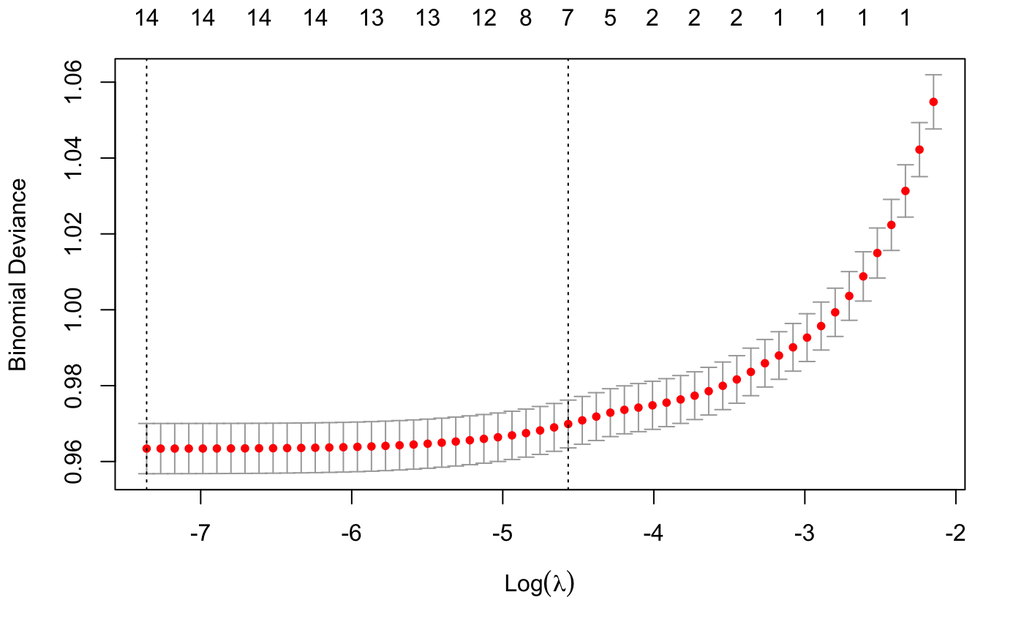

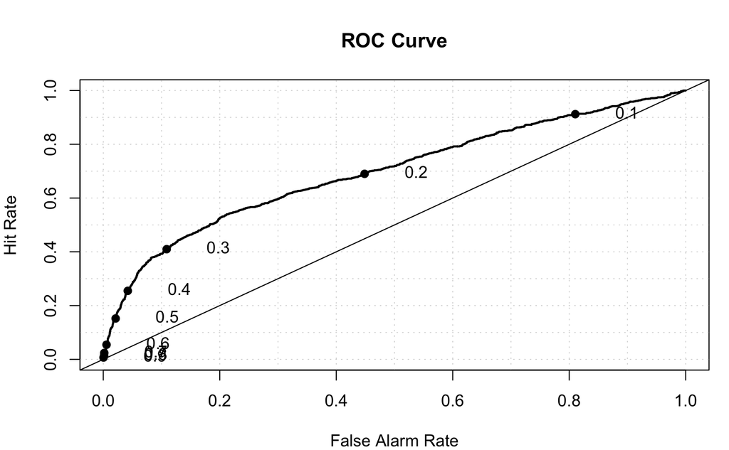

```r
cv.lasso <- cv.glmnet(x, y, alpha = 1, family = "binomial")
plot(cv.lasso)
LR.Lasso_model <- glmnet(x, y, alpha = 1, family = "binomial",
                lambda = cv.lasso$lambda.min)
pred.lr = predict(LR.Lasso_model,newx = x.test,type = "response")
roc.plot(y.test,pred.lr)

thresh = 0.35
table(pred.lr>thresh,y.test)
```

```
       y.test
           0    1
  FALSE 4366  899
  TRUE   292  443
```

```r
mean((pred.lr>thresh) == y.test)
```

```
[1] 0.8015
```

```r
coef(LR.Lasso_model)
```

```
16 x 1 sparse Matrix of class "dgCMatrix"
                            s0
(Intercept)      -1.532287e+00
LIMIT_BAL        -2.308754e-06
SEX2             -1.420156e-01
MARRIAGE1         1.538142e-01
MARRIAGE2         .
MARRIAGE3         8.191772e-02
AGE               4.312997e-03
PAY_AMT_SUM      -1.226858e-06
REGULARIZED_BILL  1.827656e-07
PAY_MEAN          5.965199e-01
PAY_RATIO1       -9.854438e-01
PAY_RATIO2       -1.631852e+00
PAY_RATIO3       -2.625287e-01
PAY_RATIO4       -2.113987e-01
PAY_RATIO5       -2.614996e-01
PAY_RATIO6       -2.745282e-01
```

## Logistic Regression with ridge:

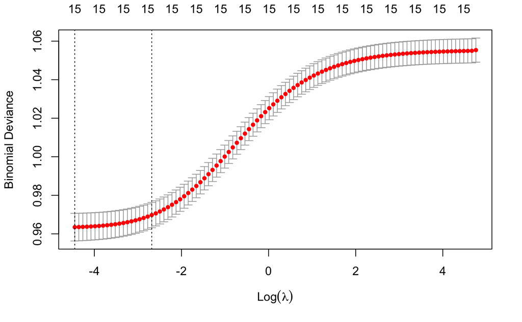

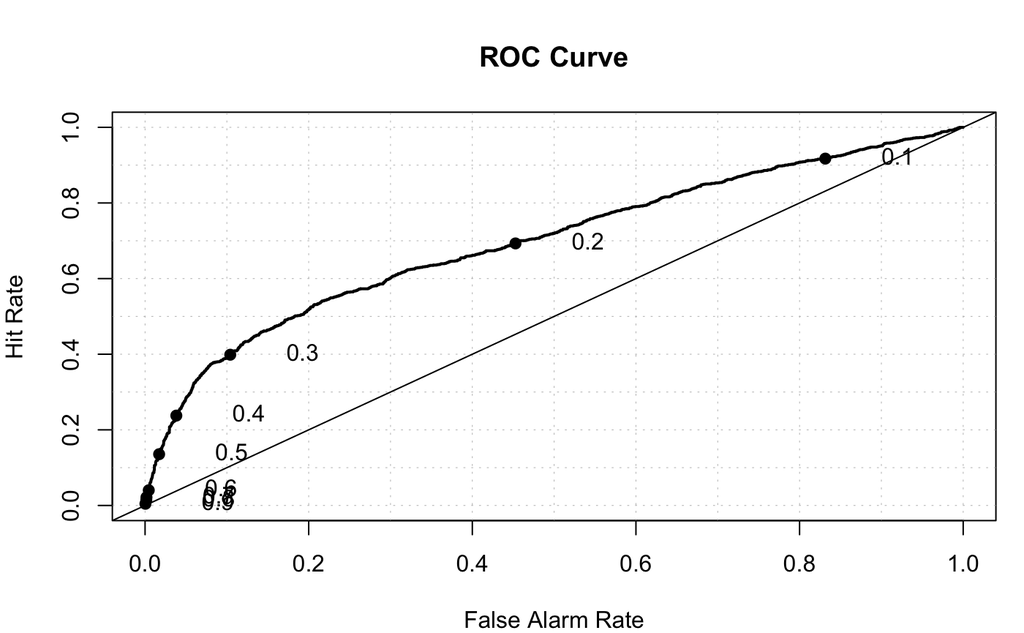

```r
cv.ridge <- cv.glmnet(x, y, alpha = 0, family = "binomial")
plot(cv.ridge)
LR.ridge_model <- glmnet(x, y, alpha = 0, family = "binomial",
                lambda = cv.ridge$lambda.min)
pred.lr = predict(LR.ridge_model,newx = x.test,type = "response")
roc.plot(y.test,pred.lr)

thresh = 0.35
table(pred.lr>thresh,y.test)
```

```
       y.test
           0    1
  FALSE 4384  918
  TRUE   274  424
```

```r
mean((pred.lr>thresh) == y.test)
```

```
[1] 0.8013333
```

```r
coef(LR.Lasso_model)
```

```
16 x 1 sparse Matrix of class "dgCMatrix"
                            s0
(Intercept)      -1.532287e+00
LIMIT_BAL        -2.308754e-06
SEX2             -1.420156e-01
MARRIAGE1         1.538142e-01
MARRIAGE2         .
MARRIAGE3         8.191772e-02
AGE               4.312997e-03
PAY_AMT_SUM      -1.226858e-06
REGULARIZED_BILL  1.827656e-07
PAY_MEAN          5.965199e-01
PAY_RATIO1       -9.854438e-01
PAY_RATIO2       -1.631852e+00
PAY_RATIO3       -2.625287e-01
PAY_RATIO4       -2.113987e-01
PAY_RATIO5       -2.614996e-01
PAY_RATIO6       -2.745282e-01
```

## LDA:

```
Large amount of unique predictions used as thresholds. Consider specifying thresholds.
```

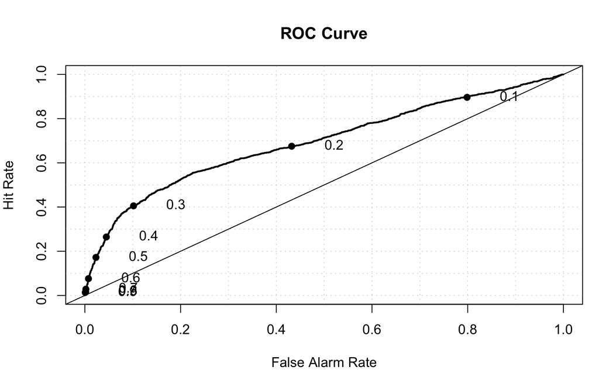

```r
roc.plot(y.test,predict(lda.fit,newdata = test_data)$posterior[,2])
```

[output not shown]

# Final results

Comparing result of these models, Logestic reggresion with lasso is slightly better than other models.

```r
coef(LR.ridge_model)
```

```
16 x 1 sparse Matrix of class "dgCMatrix"
                            s0
(Intercept)      -1.466752e+00
LIMIT_BAL        -2.241658e-06
SEX2             -1.420182e-01
MARRIAGE1         1.170550e-01
MARRIAGE2        -3.531237e-02
MARRIAGE3         8.285067e-02
AGE               4.116191e-03
PAY_AMT_SUM      -1.080781e-06
REGULARIZED_BILL  1.974756e-07
PAY_MEAN          5.508723e-01
PAY_RATIO1       -9.279484e-01
PAY_RATIO2       -1.329147e+00
PAY_RATIO3       -3.066657e-01
PAY_RATIO4       -2.611733e-01
PAY_RATIO5       -3.066540e-01
PAY_RATIO6       -3.088548e-01
```